# KCalculator

David García Sabaté

8/17/2019

# Purpose of the app

- With this calculator the user can plan the evolution of his weight loss or gain.
- To do this, he must enter his current weight, target weight, and the date on which he wants to reach the goal.
- A graph will be shown with the estimated forecast of the evolution, along with the number of calories he must lose (-), or gain (+) each day to reach the goal.

# Plans length calculation

- First, we need to calulate how many days the plan will take. In order to do so, we make some operations with the actual date and the user´s input.

`period <- unclass(difftime(target_date, today, units="days"))`

# Number of calories required and generation of the dataset with a linear model

- To calculate the number of calories the user must gain or lose, we need to take into account the formula
  $$1Kg=7000KCal$$
- Next we’ll generate a prediction using a linear model formula
  $$kilograms = actual_w + (numCalDay / 7000) * (rownumber() - 1)$$

# Plot results

- Finally, we render the results along with the graphics

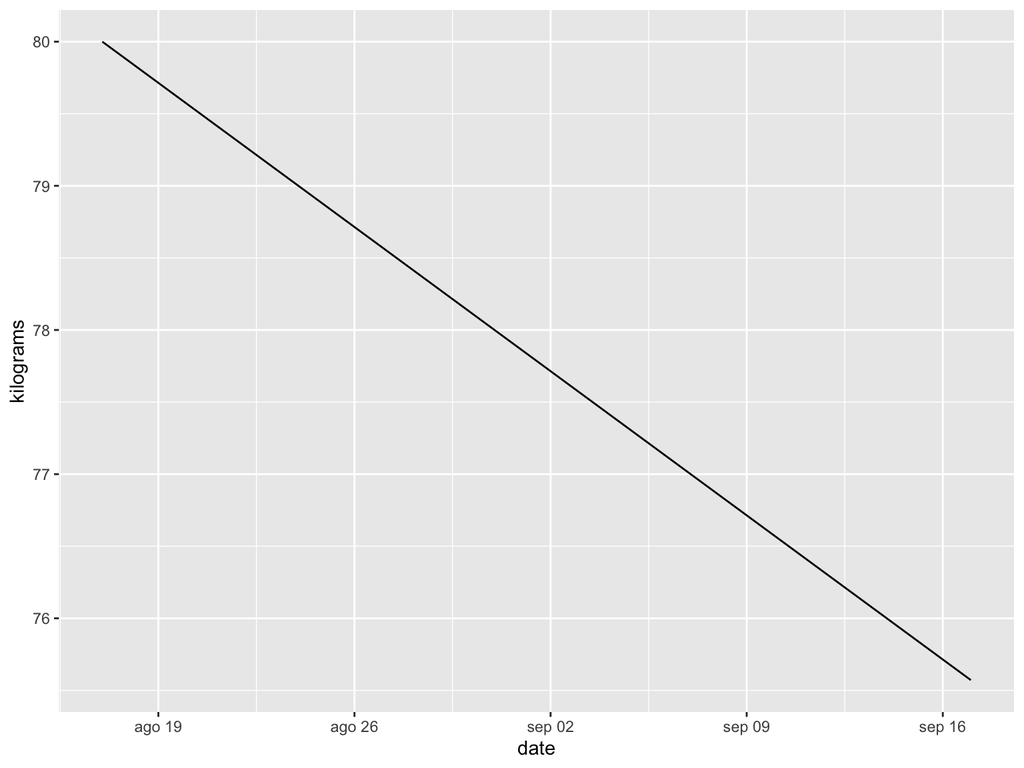